# Assignment 2 Sotaro Hirai R Notebook

Data from: Lopez-Yrigoyen M, Yang CT, Fidanza A, Cassetta L et al. Genetic programming of macrophages generates an in vitro model for the human erythroid island niche. Nat Commun 2019 Feb 20;10(1):881.

# Analysis from A1

### Prepare packages required for this analysis.

```r
# Load Biobase.
if (! require(Biobase, quietly=TRUE)) {
  if (! exists("biocLite")) {
    source("https://bioconductor.org/biocLite.R")
  }
  biocLite("Biobase")
  library(Biobase)
}
# Load GEOquery.

if (! require(GEOquery, quietly=TRUE)) {
  if (! exists("biocLite")) {
    source("https://bioconductor.org/biocLite.R")
  }
  biocLite("GEOquery")
  library(GEOquery)
}

library(knitr)
library(edgeR)
```

### Retrieve GEO data for GSE125150.

```r
GSE125150 <- getGEO("GSE125150", GSEMatrix = FALSE)
```

```
## Using locally cached version of GSE125150 found here:
## /tmp/RtmpFghh5P/GSE125150.soft.gz
```

```
## Reading file....
```

```
## Parsing....
```

[output not shown]

```
## GPL20301 (1 of 10 entities)
```

```
## GSM3564285 (2 of 10 entities)
```

```
## GSM3564286 (3 of 10 entities)
```

```
## GSM3564287 (4 of 10 entities)
```

```
## GSM3564288 (5 of 10 entities)
```

```
## GSM3564289 (6 of 10 entities)
```

```
## GSM3564290 (7 of 10 entities)
```

```
## GSM3564291 (8 of 10 entities)
```

```
## GSM3564292 (9 of 10 entities)
```

```r
kable(data.frame(head(Meta(GSE125150))), format = "html")
```

| contact_address | contact_city | contact_country | contact_email | contact_institute | contact_laboratory |
| --- | --- | --- | --- | --- | --- |
| 5 Little France Dr | Edinburgh | United Kingdom | s1419027@sms.ed.ac.uk | Centre for Regenerative Medicine | Forrester |

```r
gpl <- names(GPLList(GSE125150))[1]
gpl_info <- Meta(getGEO(gpl))
```

```
## Using locally cached version of GPL20301 found here:
## /tmp/RtmpFghh5P/GPL20301.soft
```

### Retrieve supplementary files for the differential expressions.

|  | gene_id | source | gene_version | gene_name | gene_biotype | phase | K2MT_A | K2MT_B | K2MT_C |
| --- | --- | --- | --- | --- | --- | --- | --- | --- | --- |
| ENSG00000000003 | ENSG00000000003 | ensembl | 14 | TSPAN6 | protein_coding | NA | 557 | 384 | 416 |
| ENSG00000000005 | ENSG00000000005 | ensembl_havana | 5 | TNMD | protein_coding | NA | 0 | 0 | 0 |
| ENSG00000000419 | ENSG00000000419 | ensembl_havana | 12 | DPM1 | protein_coding | NA | 1052 | 1082 | 1093 |
| ENSG00000000457 | ENSG00000000457 | ensembl_havana | 13 | SCYL3 | protein_coding | NA | 483 | 543 | 627 |
| ENSG00000000460 | ENSG00000000460 | havana | 16 | C1orf112 | protein_coding | NA | 278 | 295 | 398 |
| ENSG00000000938 | ENSG00000000938 | ensembl_havana | 12 | FGR | protein_coding | NA | 7019 | 5414 | 5931 |
| ENSG00000000971 | ENSG00000000971 | ensembl_havana | 15 | CFH | protein_coding | NA | 91 | 52 | 243 |
| ENSG00000001036 | ENSG00000001036 | ensembl_havana | 13 | FUCA2 | protein_coding | NA | 5648 | 4683 | 6030 |
| ENSG00000001084 | ENSG00000001084 | havana | 10 | GCLC | protein_coding | NA | 20047 | 18149 | 23182 |
| ENSG00000001167 | ENSG00000001167 | ensembl_havana | 14 | NFYA | protein_coding | NA | 2588 | 2366 | 2766 |
| ENSG00000001460 | ENSG00000001460 | ensembl_havana | 17 | STPG1 | protein_coding | NA | 137 | 76 | 83 |
| ENSG00000001461 | ENSG00000001461 | ensembl_havana | 16 | NIPAL3 | protein_coding | NA | 1025 | 562 | 730 |
| ENSG00000001497 | ENSG00000001497 | ensembl_havana | 16 | LAS1L | protein_coding | NA | 1155 | 974 | 1178 |
| ENSG00000001561 | ENSG00000001561 | ensembl_havana | 6 | ENPP4 | protein_coding | NA | 122 | 97 | 128 |
| ENSG00000001617 | ENSG00000001617 | havana | 11 | SEMA3F | protein_coding | NA | 9 | 4 | 30 |

### Clean data if needed.

```
## named integer(0)
```

The data provided was thorough enough to have HGNC symbols for each gene, so there was no need for identifier mapping.

### Filter any uninformative or weakly expressed data after converting counts to cpm.

```
## [1] 60675    15
```

Started with 60675 genes. Filtered down to 13872 genes.

### Plotting the density distribution of my filtered and cpm-converted data.

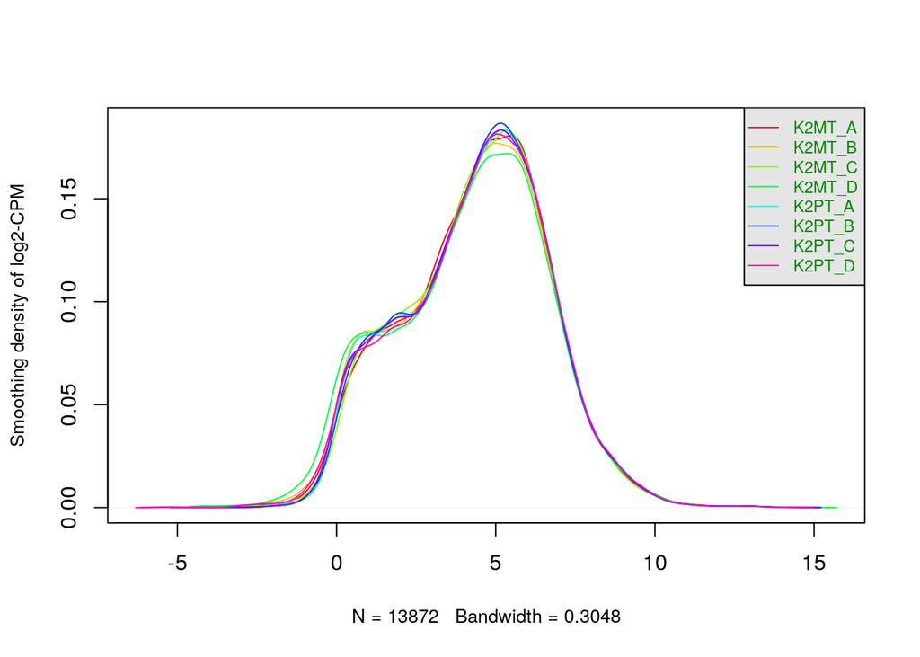

### Plot and compare the distribution between pre- and post-normalization.

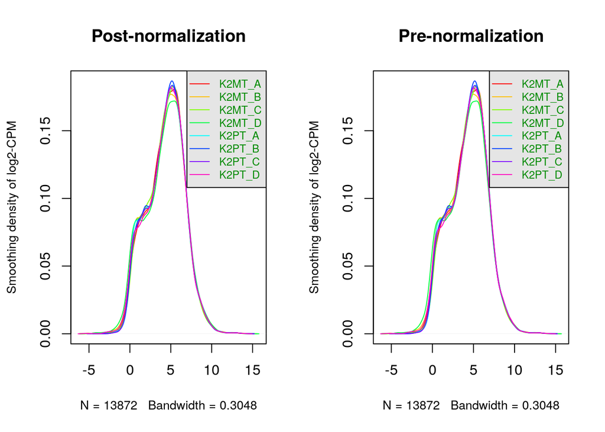

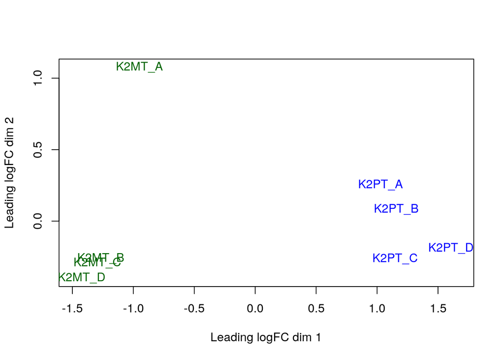

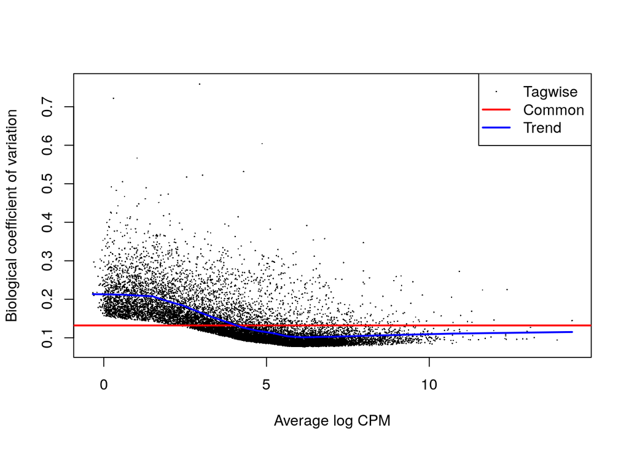

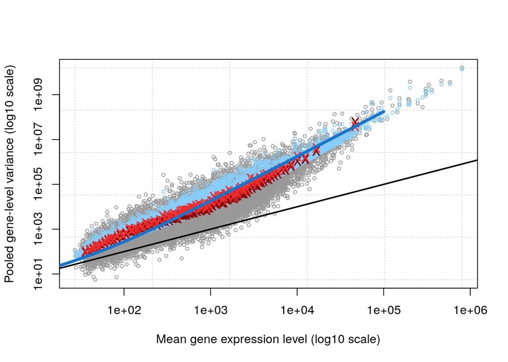

### Save the data.

```r
# Convert back to data.frame so that we can associate gene names with the counts again, because
# matrices cannot hold strings and numerics together.

a <- as.data.frame(normalized_counts)
b <- c("gene_id", colnames(a))
normalized_counts <- merge(expr_filtered[c(2, 5)], cbind(rownames(a), a), by.x="gene_id", by.y="rownames(a)")

write.table(normalized_counts, "~/GSE125150_normalized_counts.txt", sep = "\t")
```

# Analysis for A2

## Introduction

In the previous assignment, data was retrieved from GEO with the id GSE125150. This data is explores how KLF-1 expression affects macrophage function during the maturation of erythrocyte, in humans. After the raw gene count data underwent conversion to cpm, any uninformative or weakly expressed genes were omitted. Then, the cleaned data was normalized using log2(cpm) and further analysis with MDS plot and mean-variance relationship showed that the samples clustered based on treatment (KLF-1+ vs. KLF-1-) and that the data followed a negative binomial distribution. After cleaning and normalization, the dataset was reduced to 13872 genes starting from 60675.

## Differential Expression Analysis

### Prepare packages required for this analysis.

### Load normalized data from previous assignment.

|  | gene_id | gene_name | K2MT_A | K2MT_B | K2MT_C |
| --- | --- | --- | --- | --- | --- |
| 1 | ENSG00000000003 | TSPAN6 | 15.319013 | 11.330247 | 10.76981 |
| 2 | ENSG00000000419 | DPM1 | 28.932858 | 31.925330 | 28.29664 |
| 3 | ENSG00000000457 | SCYL3 | 13.283812 | 16.021677 | 16.23238 |
| 4 | ENSG00000000460 | C1orf112 | 7.645755 | 8.704226 | 10.30381 |
| 5 | ENSG00000000938 | FGR | 193.041568 | 159.744673 | 153.54745 |

### Prepare for creating a heatmap and downstream analysis.

|  | K2MT_A | K2MT_B | K2MT_C | K2MT_D | K2PT_A | K2PT_B | K2PT_C | K2PT_D |
| --- | --- | --- | --- | --- | --- | --- | --- | --- |
| ENSG00000000003 | 15.3190132 | 11.3302465 | 10.7698090 | 9.5867689 | 12.2707113 | 12.9845092 | 12.9326410 | 11.9987637 |
| ENSG00000000419 | 28.9328579 | 31.9253300 | 28.2966376 | 32.5950142 | 32.9090929 | 29.9394882 | 33.9172138 | 33.0616823 |
| ENSG00000000457 | 13.2838121 | 16.0216767 | 16.2323804 | 16.2701163 | 14.7417012 | 13.9502991 | 15.2367323 | 16.7556700 |
| ENSG00000000460 | 7.6457552 | 8.7042258 | 10.3038077 | 8.5459197 | 9.6593242 | 11.1065843 | 10.6533250 | 10.0108029 |
| ENSG00000000938 | 193.0415681 | 159.7446733 | 153.5474454 | 172.8631385 | 228.4261697 | 225.6729162 | 183.3115154 | 138.3526089 |
| ENSG00000000971 | 2.5027472 | 1.5343042 | 6.2910182 | 1.5612738 | 13.5904445 | 17.8134589 | 29.7054341 | 25.5358305 |
| ENSG00000001036 | 155.3353436 | 138.1758968 | 156.1104528 | 172.3153232 | 187.0651681 | 180.1198240 | 180.5366959 | 180.9281038 |
| ENSG00000001084 | 551.3469604 | 535.5016764 | 600.1579630 | 765.6815361 | 504.2504185 | 423.1501317 | 445.1107833 | 461.9405701 |
| ENSG00000001167 | 71.1770307 | 69.8108417 | 71.6088744 | 74.3385451 | 67.6714283 | 68.6783958 | 67.5123503 | 65.4133785 |
| ENSG00000001460 | 3.7678722 | 2.2424446 | 2.1487840 | 2.6842953 | 1.9374807 | 3.1656448 | 2.1306650 | 2.8872765 |

[output cut: 990 more lines]

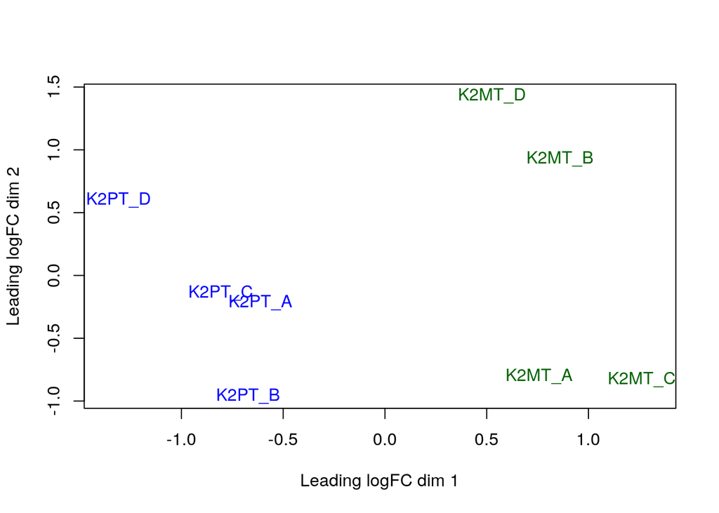

### Create a model, calculate p-values, and apply multiple hypothesis testing.

|  | sample | treatment |
| --- | --- | --- |
| K2MT_A | A | K2MT |
| K2MT_B | B | K2MT |
| K2MT_C | C | K2MT |
| K2MT_D | D | K2MT |
| K2PT_A | A | K2PT |
| K2PT_B | B | K2PT |
| K2PT_C | C | K2PT |
| K2PT_D | D | K2PT |

| (Intercept) | samples$treatmentK2PT |
| --- | --- |
| 1 | 0 |
| 1 | 0 |
| 1 | 0 |
| 1 | 0 |
| 1 | 1 |
| 1 | 1 |
| 1 | 1 |
| 1 | 1 |

|  | gene_id | gene_name | logFC | AveExpr | t | P.Value | adj.P.Val | B |
| --- | --- | --- | --- | --- | --- | --- | --- | --- |
| 5581 | ENSG00000136999 | NOV | 34.8878889 | 21.7923391 | 26.503010 | 3.407156e-09 | 2.351494e-05 | 1.8392163386 |
| 6348 | ENSG00000143537 | ADAM15 | 200.0473484 | 182.1822054 | 26.172486 | 3.769768e-09 | 2.351494e-05 | 1.8340487945 |
| 824 | ENSG00000068078 | FGFR3 | 6.5091055 | 4.3713736 | 24.021126 | 7.519569e-09 | 2.351494e-05 | 1.7953166305 |
| 5062 | ENSG00000133101 | CCNA1 | -16.7521384 | 10.3580613 | -23.547672 | 8.824713e-09 | 2.351494e-05 | 1.7854175230 |
| 5416 | ENSG00000135931 | ARMC9 | -109.5596022 | 91.4099046 | -23.496294 | 8.981007e-09 | 2.351494e-05 | 1.7843091995 |
| 2556 | ENSG00000106123 | EPHB6 | 38.4462977 | 25.2717716 | 23.135319 | 1.017082e-08 | 2.351494e-05 | 1.7763249704 |
| 2957 | ENSG00000110651 | CD81 | -320.3355784 | 811.8889692 | -20.130707 | 3.102736e-08 | 6.120664e-05 | 1.6935887625 |
| 8878 | ENSG00000167779 | IGFBP6 | 24.4597815 | 15.2794147 | 19.770062 | 3.585319e-08 | 6.120664e-05 | 1.6812449698 |
| 1515 | ENSG00000090776 | EFNB1 | 86.5537521 | 84.0795039 | 19.518926 | 3.971019e-08 | 6.120664e-05 | 1.6722744820 |
| 4625 | ENSG00000128918 | ALDH1A2 | -169.1725525 | 150.0162915 | -19.116146 | 4.690625e-08 | 6.506835e-05 | 1.6572034414 |

[output cut: 990 more lines]

[output not shown]

```
## [1] 2841
```

```
## [1] 1337
```

For Multiple Hypothesis Testing, I used the BH method. According to the documentation and literature, BH method controls for the false discovery rate (a less stringent condition than family-wise error rate) and therefore is a more powerful method than those that control for family-wise error rate. My dataset allows many genes to pass even with the stringent condition (with BH), so I decided to use BH. Before correction, 2841 genes passed a cutoff of 0.01, and after correction with the BH method, 1337 genes passed. With a cutoff of 0.05, there were 2859 (after correction) and I considered this as excessive, so I decided to make the cutoff more strict. I could have made the cutoff higher to 0.001; however, I was afraid I would disregard interesting genes, so I kept the cutoff at 0.01 as it is a generally accepted p-value for high significance.

### Create heat map based on p-value cutoff.

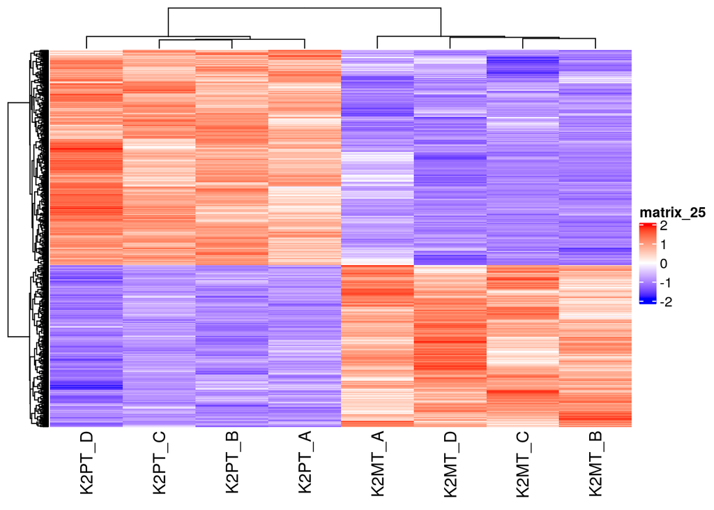

Based on the heatmap, the conditions (KLF-1+ vs. KLF-1-) cluster together. All the samples in KLF-1+ (K2PT) share similar differential expression profiles and all the samples in KLF-1- (K2MT) share similar differential expression profiles.

## ORA

### Retrieve thresholded list for upregulated and downregulated genes

```
##  [1] B4GALT6       MAP7D1        AKAP12        CLTCL1        ABLIM1
##  [6] IL10          NDUFAF5       RP11-550P17.5 TRGV6         DNM1L
## 13869 Levels: A1BG-AS1 A2M A2M-AS1 AAAS AACS AADAC AADAT AAED1 AAGAB ... ZZZ3
```

```
##  [1] CCNA1   ARMC9   CD81    ALDH1A2 ID2     MAN1A1  PLP2    CTNNB1
##  [9] H6PD    HS3ST1
## 13869 Levels: A1BG-AS1 A2M A2M-AS1 AAAS AACS AADAC AADAT AAED1 AAGAB ... ZZZ3
```

### ORA with g:Profiler

Below are the images of related terms for the upregulated genes:

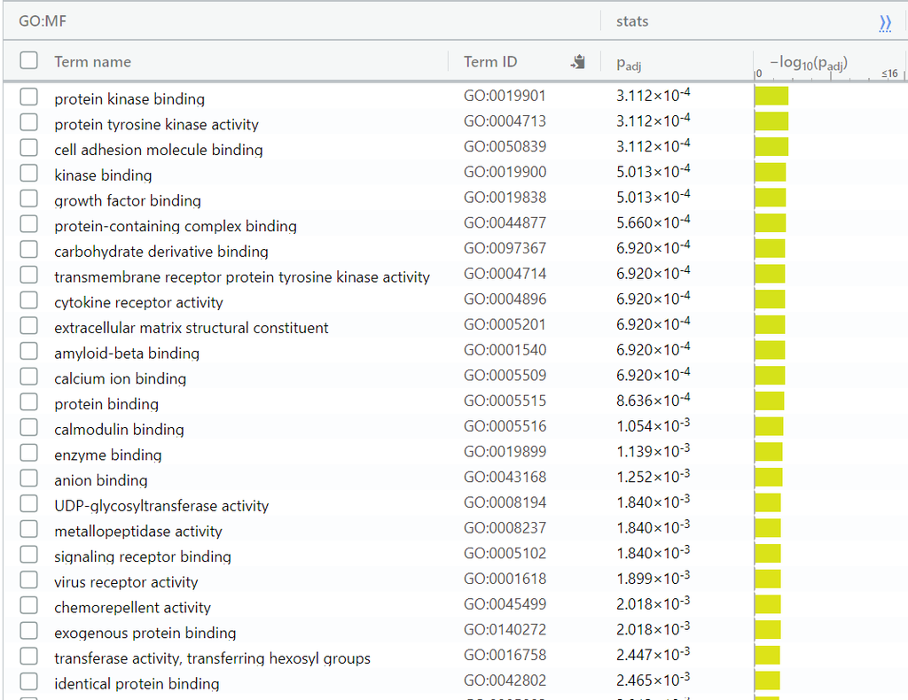

```r
knitr::include_graphics("upregulated_genes_1.png")
```

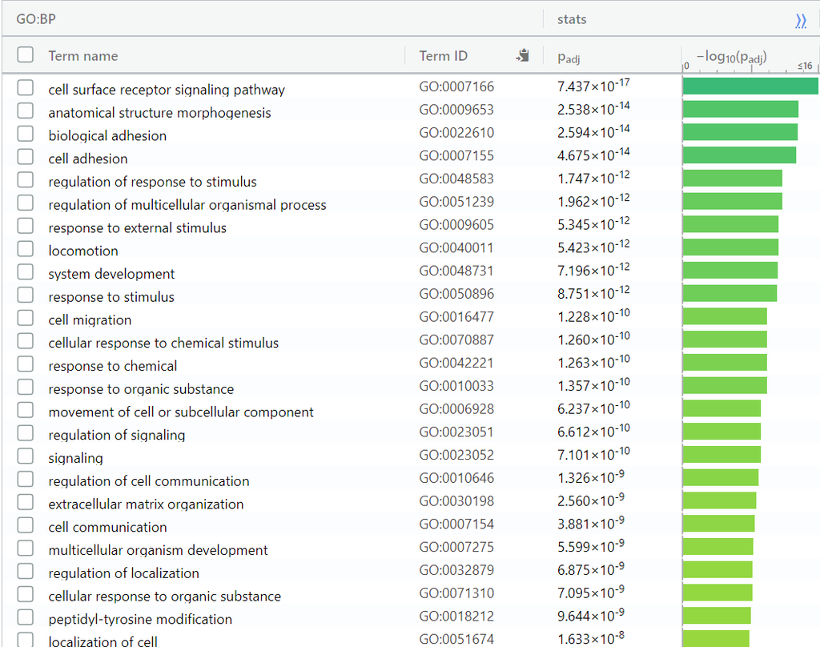

```r
knitr::include_graphics("upregulated_genes_2.png")
```

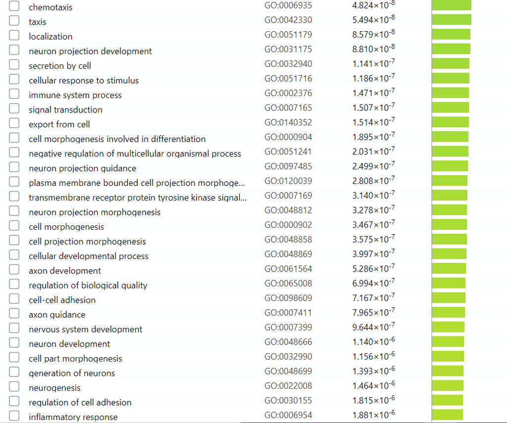

```r
knitr::include_graphics("upregulated_genes_3.png")
```

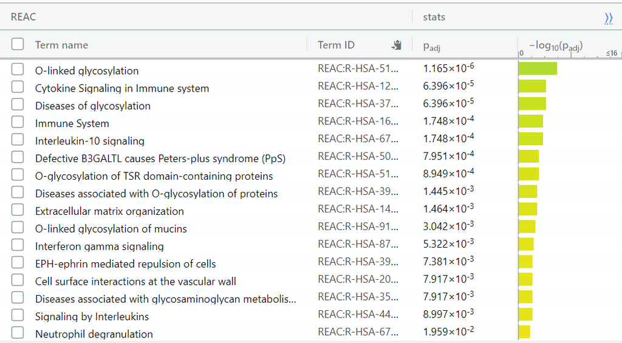

```r
knitr::include_graphics("upregulated_genes_4.png")
```

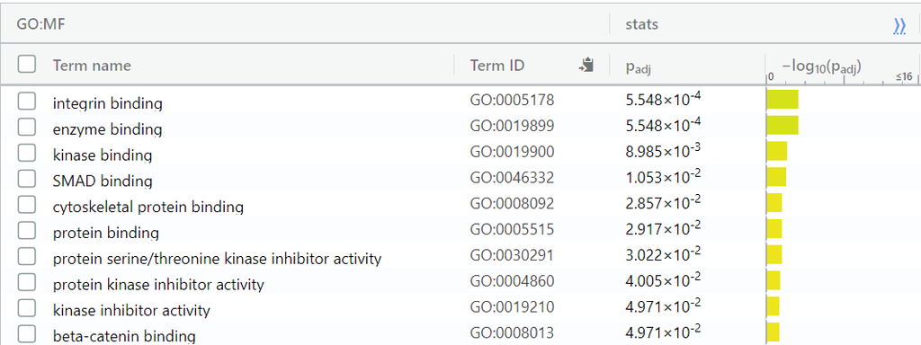

```r
knitr::include_graphics("downregulated_genes_1.png")
```

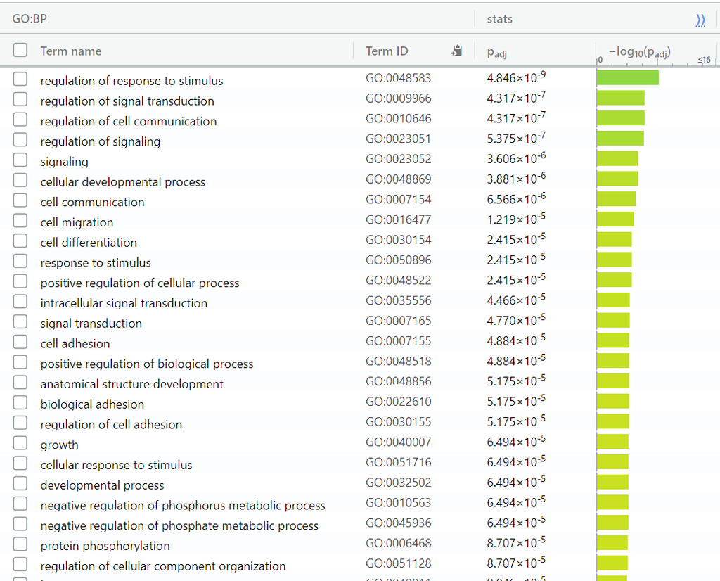

```r
knitr::include_graphics("downregulated_genes_2.png")
```

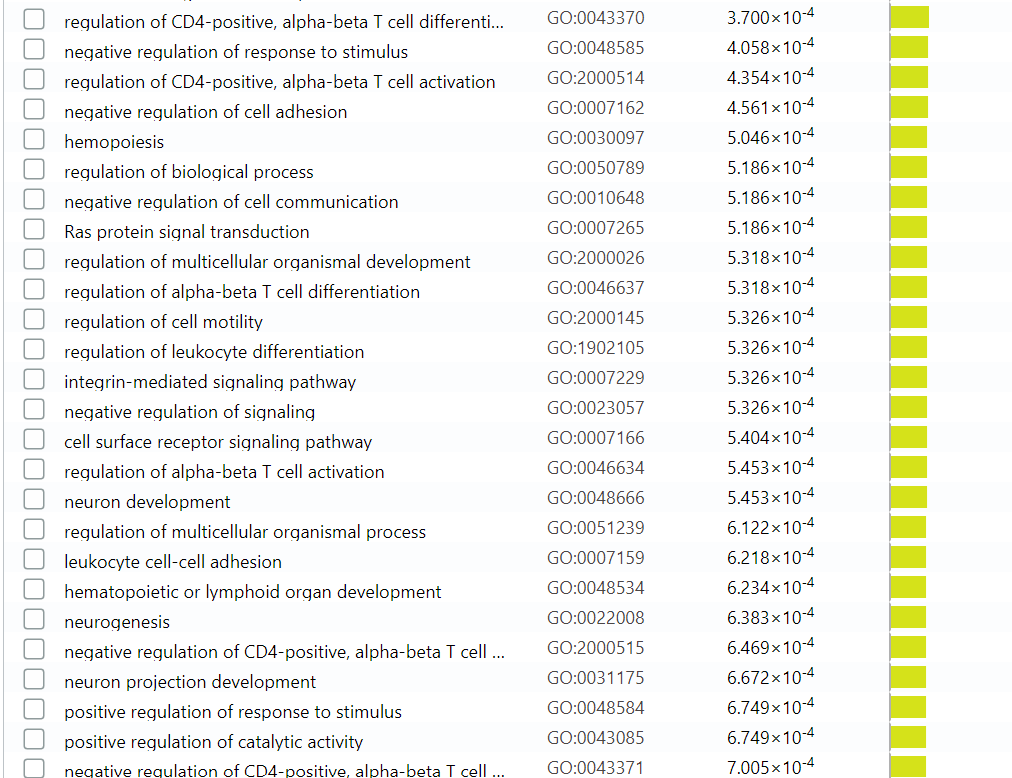

```r
knitr::include_graphics("downregulated_genes_3.png")
```

### Interpretations

The results of this analysis broadly supports the original paper’s conclusion, in that KLF-1 induction does lead to differentiation to macrophages that are involved in erythrocyte maturation. The result of g:Profiler shows that upregulated genes are involved in immune system processes, as well as cell-cell adhesion and communication. Also, protein kinase activity seems to be upregulated, and this makes sense because kinases are often related with signalling pathways and activations. Interestingly, these genes are also involved in neuronal processes which could potentially unveil interesting relationships between immune cells that are resident in umbilical cords vs. near neurons. Furthermore, the downregulated genes appear to be involved in kinase inhibition, which corresponds to the upregulated genes. One interesting process that is shown to be downregulated in KLF-1+ macrophages is the regulation of CD4 T cells. This could possibly be due to the fact that these macrophages are obligates to helping the maturation of erythrocytes.

# References

Lopez-Yrigoyen M, Yang CT, Fidanza A, Cassetta L et al. Genetic programming of macrophages generates an in vitro model for the human erythroid island niche. Nat Commun 2019 Feb 20;10(1):881.

Ritchie ME, Phipson B, Wu D, Hu Y, Law CW, Shi W, Smyth GK (2015). “limma powers differential expression analyses for RNA-sequencing and microarray studies.” Nucleic Acids Research, 43(7), e47. doi: 10.1093/nar/gkv007.

Robinson MD, McCarthy DJ, Smyth GK (2010). “edgeR: a Bioconductor package for differential expression analysis of digital gene expression data.” Bioinformatics, 26(1), 139-140. doi: 10.1093/bioinformatics/btp616.

Uku Raudvere, Liis Kolberg, Ivan Kuzmin, Tambet Arak, Priit Adler, Hedi Peterson, Jaak Vilo: g:Profiler: a web server for functional enrichment analysis and conversions of gene lists (2019 update) Nucleic Acids Research 2019; doi:10.1093/nar/gkz369